# Gráficos con ggplot2 (B): más elementos

## Extensión: coordenadas

- coord_cartesian()
- coord_flip()
- coord_fixed()
- coord_polar()
- Es el sistema por defecto. Ya lo hemos usado para **hacer zoom sin eliminar datos**

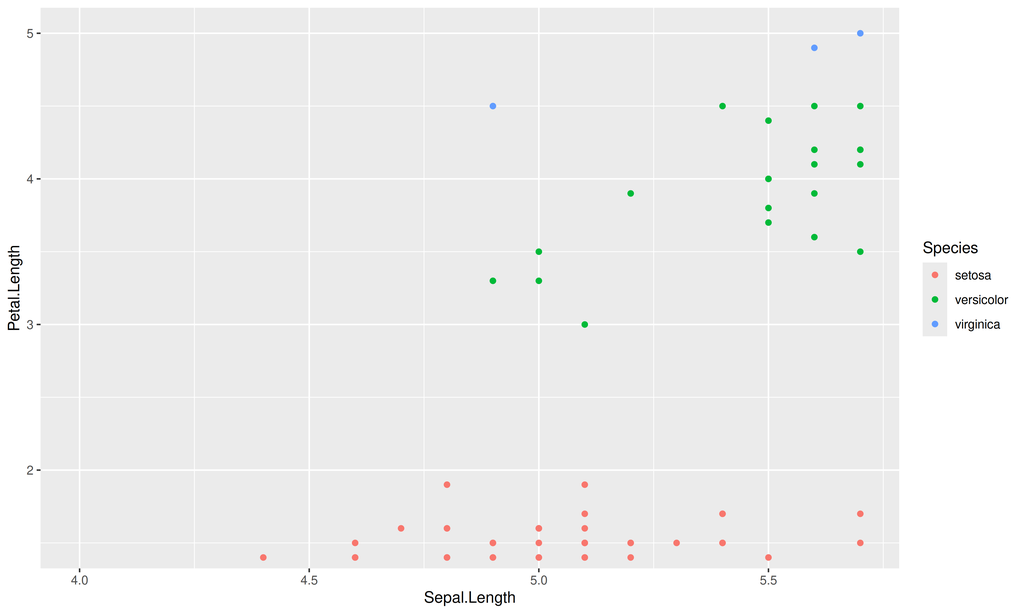

```r
p + coord_cartesian(xlim = c(4, 5.7), ylim = c(1.5, 5))
```

- Intercambia los ejes X e Y (útil, p.ej., en gráficos de barras con etiquetas largas). Hoy en día suele bastar con intercambiar las variables en `aes()`

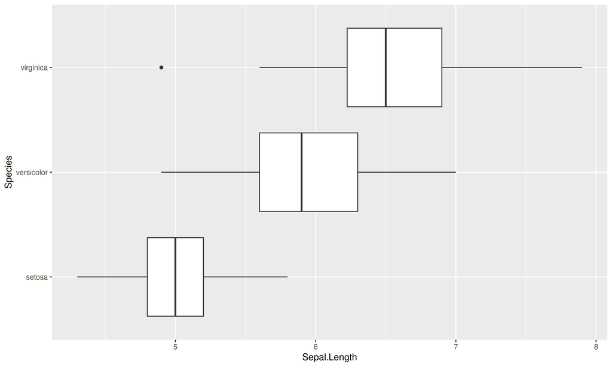

```r
ggplot(iris, aes(Species, Sepal.Length)) + geom_boxplot() + coord_flip()
```

- Fija la relación entre las unidades de los ejes: con `ratio = 1`, una unidad en X mide lo mismo que una unidad en Y

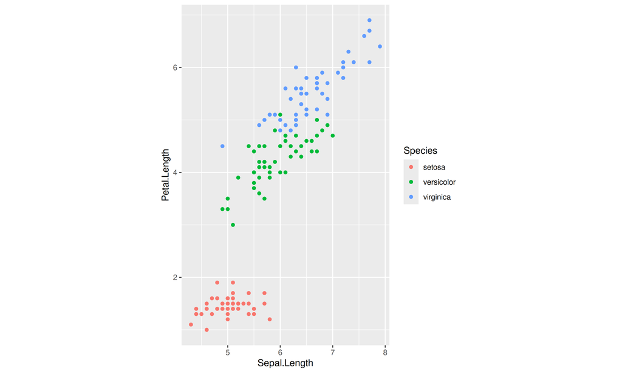

```r
p + coord_fixed(ratio = 1)
```

- Coordenadas polares. Así se hacen, p.ej., los gráficos de tarta (que no suelen ser buena idea!)

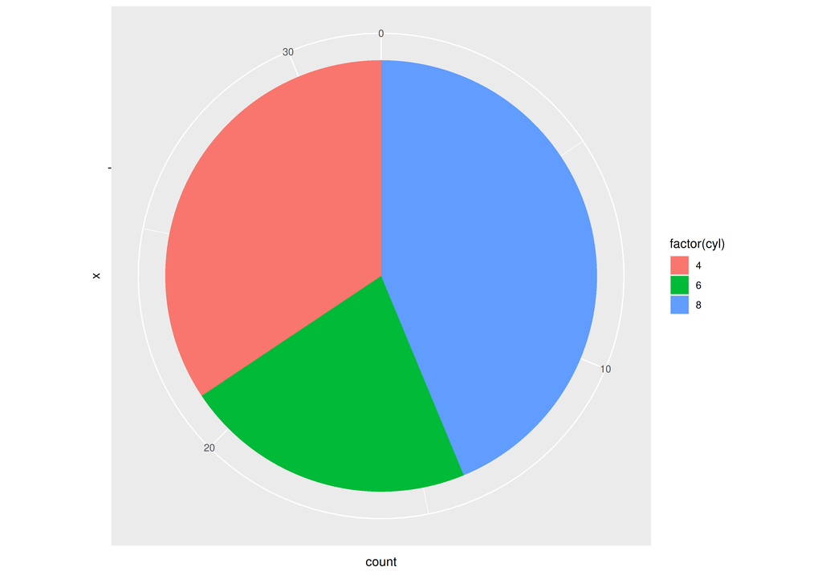

```r
ggplot(mtcars, aes(x = "", fill = factor(cyl))) + geom_bar() + coord_polar(theta = "y")
```

## Extensión: texto alternativo (gráficos accesibles)

- Las personas que usan lectores de pantalla no “ven” el gráfico. Con `labs(alt = ...)` podemos añadir un **texto alternativo** que describa lo que muestra:

```r
p + labs(alt = "Gráfico de puntos: la longitud del pétalo crece con
                la del sépalo; los lirios setosa forman un grupo aparte,
                con pétalos mucho más cortos")
```

- En Quarto también se puede poner con la opción de chunk `#| fig-alt: "..."`
- Un buen texto alternativo no describe el código, sino **el mensaje del gráfico**